# Planification of bats survey project in Plumas National Forest

### Author: “Derek Corcoran”

### Last update 2015-05-01

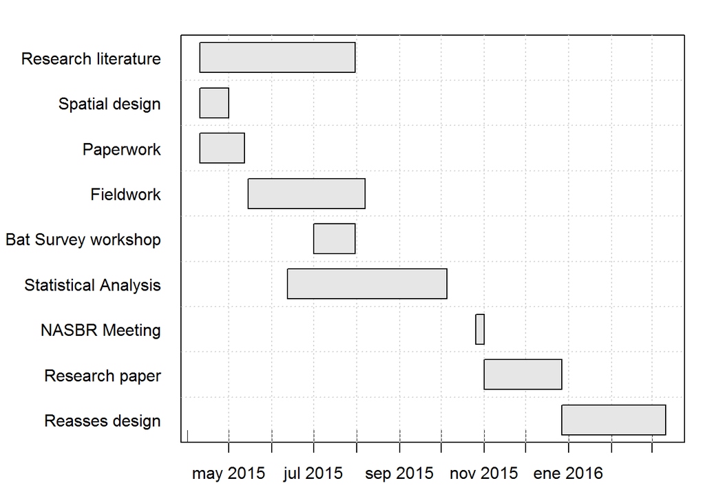

**Research literature:** Ongoing, I will keep on reading and updating about models, detectors and/or bat ecology until at least July the 31st

**Spatial design:** Ongoing, the work done so far can be found [here](http://rpubs.com/derek_corcoran/bats_california), the first sampling design draft will be available on friday the 1st of may. For more information and scripts go [here](https://github.com/derek-corcoran-barrios/Bats_California2)

**Paperwork:** Ongoing,to be finished on May 10th, what is left to do, drivers licence, harassment seminar and purchase cards.

**May fieldwork:** From the 15th till the 7th of August.

**bat survey workshop:**Unsure of place and/or exact date.

**Statistical analysis:** From the June 12th till the 5th of October, this includes sending an abstract to the NASABR meeting

**NASBR meeting:** Participation in the 45th [North American Society for bat research](https://www.nasbr.org/) meeting in Monterrey California.

**Reasses design:** strating on the last week of December I will start reassesing the design for next year.